## 1. Purpose and analysis boundary

This notebook performs a read-only accuracy review of the five formal edge-weight bootstrap results produced in Step 07.

It does not estimate networks, rerun bootstrap resampling, calculate centrality, conduct case-dropping bootstrap, perform NCT, analyse education groups, or interpret political change.

Bootstrap intervals are treated as indicators of estimation accuracy. Whether an interval includes zero is not treated as a formal significance test.

## 2. Locate the project

```r
current_dir <- normalizePath(
  ".",
  winslash = "/",
  mustWork = TRUE
)

if (
  file.exists(
    file.path(
      current_dir,
      "ANES_dissertation.Rproj"
    )
  )
) {
  project_root <- current_dir
} else if (
  basename(current_dir) == "notebooks" &&
    file.exists(
      file.path(
        dirname(current_dir),
        "ANES_dissertation.Rproj"
      )
    )
) {
  project_root <- dirname(current_dir)
} else {
  stop(
    "Project root could not be identified. Open the ANES_dissertation RStudio project before knitting."
  )
}

knitr::opts_knit$set(
  root.dir = project_root
)

project_root
```

```
## [1] "D:/ANES_code/ANES_dissertation"
```

## 3. Define input and output locations

```r
formal_table_dir <- file.path(
  project_root,
  "outputs",
  "tables",
  "formal"
)

formal_model_dir <- file.path(
  project_root,
  "outputs",
  "models",
  "formal"
)

formal_figure_dir <- file.path(
  project_root,
  "outputs",
  "figures",
  "formal"
)

log_dir <- file.path(
  project_root,
  "outputs",
  "logs"
)

dir.create(
  formal_figure_dir,
  recursive = TRUE,
  showWarnings = FALSE
)

dir.create(
  log_dir,
  recursive = TRUE,
  showWarnings = FALSE
)

point_edge_file <- file.path(
  formal_table_dir,
  "07_formal_five_wave_edge_weights.csv"
)

bootstrap_summary_file <- file.path(
  formal_table_dir,
  "07_formal_five_wave_edge_bootstrap_summary.csv"
)

bootstrap_diagnostics_file <- file.path(
  formal_table_dir,
  "07_formal_five_wave_edge_bootstrap_diagnostics.csv"
)

bootstrap_validation_file <- file.path(
  formal_table_dir,
  "07_formal_five_wave_edge_bootstrap_validation.csv"
)

point_diagnostics_file <- file.path(
  formal_table_dir,
  "07_formal_five_wave_point_network_diagnostics.csv"
)

model_files <- c(
  file.path(
    formal_model_dir,
    "07_formal_five_wave_networks_gamma050.rds"
  ),
  file.path(
    formal_model_dir,
    paste0(
      "07_formal_edge_bootstrap_",
      c(2004, 2012, 2016, 2020, 2024),
      "_1000.rds"
    )
  )
)

table_input_files <- c(
  point_edge_file,
  bootstrap_summary_file,
  bootstrap_diagnostics_file,
  bootstrap_validation_file,
  point_diagnostics_file
)

all_source_files <- c(
  table_input_files,
  model_files
)

missing_source_files <- all_source_files[
  !file.exists(all_source_files)
]

if (length(missing_source_files) > 0L) {
  stop(
    paste(
      "Required Step-07 source files are missing:",
      paste(missing_source_files, collapse = "; ")
    )
  )
}
```

## 4. Record source-file provenance

```r
model_md5_before <- unname(
  tools::md5sum(model_files)
)

input_inventory <- data.frame(
  File = basename(all_source_files),
  Path = normalizePath(
    all_source_files,
    winslash = "/"
  ),
  Size_bytes = file.info(all_source_files)$size,
  Last_modified = format(
    file.info(all_source_files)$mtime,
    "%Y-%m-%d %H:%M:%S"
  ),
  MD5 = unname(
    tools::md5sum(all_source_files)
  ),
  stringsAsFactors = FALSE
)

input_inventory_file <- file.path(
  formal_table_dir,
  "07A_input_inventory.csv"
)

write.csv(
  input_inventory,
  input_inventory_file,
  row.names = FALSE,
  na = ""
)

input_inventory
```

```
##                                                  File
## 1                07_formal_five_wave_edge_weights.csv
## 2      07_formal_five_wave_edge_bootstrap_summary.csv
## 3  07_formal_five_wave_edge_bootstrap_diagnostics.csv
## 4   07_formal_five_wave_edge_bootstrap_validation.csv
## 5   07_formal_five_wave_point_network_diagnostics.csv
## 6           07_formal_five_wave_networks_gamma050.rds
## 7              07_formal_edge_bootstrap_2004_1000.rds
## 8              07_formal_edge_bootstrap_2012_1000.rds
## 9              07_formal_edge_bootstrap_2016_1000.rds
## 10             07_formal_edge_bootstrap_2020_1000.rds
## 11             07_formal_edge_bootstrap_2024_1000.rds
##                                                                                                       Path
## 1                D:/ANES_code/ANES_dissertation/outputs/tables/formal/07_formal_five_wave_edge_weights.csv
## 2      D:/ANES_code/ANES_dissertation/outputs/tables/formal/07_formal_five_wave_edge_bootstrap_summary.csv
```

[output cut: 21 more lines]

## 5. Read the validated Step-07 outputs

```r
point_edges <- read.csv(
  point_edge_file,
  check.names = FALSE
)

bootstrap_summary <- read.csv(
  bootstrap_summary_file,
  check.names = FALSE
)

bootstrap_diagnostics <- read.csv(
  bootstrap_diagnostics_file,
  check.names = FALSE
)

bootstrap_validation <- read.csv(
  bootstrap_validation_file,
  check.names = FALSE
)

point_diagnostics <- read.csv(
  point_diagnostics_file,
  check.names = FALSE
)

assert_columns <- function(
  data,
  required_columns,
  object_name
) {
  missing_columns <- setdiff(
    required_columns,
    names(data)
  )

  if (length(missing_columns) > 0L) {
    stop(
      paste(
        object_name,
        "is missing required columns:",
        paste(missing_columns, collapse = ", ")
      )
    )
  }
}

assert_columns(
  point_edges,
  c(
    "Wave",
    "Node_1",
    "Node_2",
    "Edge_weight",
    "Retained_under_EBICglasso"
  ),
  "Point-edge table"
)

assert_columns(
  bootstrap_summary,
  c(
    "Wave",
    "node1",
    "node2",
    "sample",
    "mean",
    "sd",
    "CIlower",
    "CIupper",
    "q2.5",
    "q97.5",
    "prop0"
  ),
  "Bootstrap-summary table"
)

assert_columns(
  bootstrap_diagnostics,
  c(
    "Wave",
    "Requested_bootstraps",
    "Returned_bootstraps",
    "Captured_warning_n",
    "All_validation_checks_passed"
  ),
  "Bootstrap-diagnostics table"
)

assert_columns(
  bootstrap_validation,
  c(
    "Wave",
    "Check",
    "Passed"
  ),
  "Bootstrap-validation table"
)
```

## 6. Join point estimates and bootstrap results

```r
expected_waves <- c(
  2004L,
  2012L,
  2016L,
  2020L,
  2024L
)

point_edges$Wave <- as.integer(
  point_edges$Wave
)

bootstrap_summary$Wave <- as.integer(
  bootstrap_summary$Wave
)

bootstrap_diagnostics$Wave <- as.integer(
  bootstrap_diagnostics$Wave
)

bootstrap_validation$Wave <- as.integer(
  bootstrap_validation$Wave
)

point_edges$Edge_weight <- as.numeric(
  point_edges$Edge_weight
)

point_edges$Retained_under_EBICglasso <-
  toupper(
    as.character(
      point_edges$Retained_under_EBICglasso
    )
  ) == "TRUE"

bootstrap_numeric_columns <- c(
  "sample",
  "mean",
  "sd",
  "CIlower",
  "CIupper",
  "q2.5",
  "q97.5",
  "prop0"
)

for (column_name in bootstrap_numeric_columns) {
  bootstrap_summary[[column_name]] <-
    as.numeric(
      bootstrap_summary[[column_name]]
    )
}

point_edges$Edge_ID <- paste(
  pmin(
    point_edges$Node_1,
    point_edges$Node_2
  ),
  pmax(
    point_edges$Node_1,
    point_edges$Node_2
  ),
  sep = "--"
)

bootstrap_summary$Edge_ID <- paste(
  pmin(
    bootstrap_summary$node1,
    bootstrap_summary$node2
  ),
  pmax(
    bootstrap_summary$node1,
    bootstrap_summary$node2
  ),
  sep = "--"
)

review_joined <- merge(
  point_edges,
  bootstrap_summary,
  by = c(
    "Wave",
    "Edge_ID"
  ),
  all = FALSE,
  sort = FALSE
)

if (nrow(review_joined) == 0L) {
  stop(
    "The point-edge and bootstrap tables could not be joined."
  )
}

edge_accuracy <- data.frame(
  Wave = review_joined$Wave,
  Edge_ID = review_joined$Edge_ID,
  Node_1 = review_joined$Node_1,
  Node_2 = review_joined$Node_2,
  Point_edge = review_joined$Edge_weight,
  Retained_under_EBICglasso =
    review_joined$Retained_under_EBICglasso,
  Bootstrap_mean = review_joined$mean,
  Bootstrap_sd = review_joined$sd,
  Reported_CI_lower = review_joined$CIlower,
  Reported_CI_upper = review_joined$CIupper,
  Percentile_2_5 = review_joined[["q2.5"]],
  Percentile_97_5 = review_joined[["q97.5"]],
  Bootstrap_zero_proportion =
    review_joined$prop0,
  stringsAsFactors = FALSE
)

edge_accuracy$Reported_CI_width <-
  edge_accuracy$Reported_CI_upper -
  edge_accuracy$Reported_CI_lower

edge_accuracy$Percentile_interval_width <-
  edge_accuracy$Percentile_97_5 -
  edge_accuracy$Percentile_2_5

edge_accuracy$Percentile_interval_includes_zero <-
  edge_accuracy$Percentile_2_5 <= 0 &
  edge_accuracy$Percentile_97_5 >= 0

edge_accuracy$Bootstrap_mean_minus_point <-
  edge_accuracy$Bootstrap_mean -
  edge_accuracy$Point_edge

edge_accuracy$Retained_edge_sign_reproduced <-
  ifelse(
    edge_accuracy$Retained_under_EBICglasso,
    sign(edge_accuracy$Point_edge) ==
      sign(edge_accuracy$Bootstrap_mean),
    NA
  )

edge_accuracy <- edge_accuracy[
  order(
    edge_accuracy$Wave,
    edge_accuracy$Node_1,
    edge_accuracy$Node_2
  ),
]

row.names(edge_accuracy) <- NULL
```

## 7. Validation gate

```r
numeric_review_columns <- c(
  "Point_edge",
  "Bootstrap_mean",
  "Bootstrap_sd",
  "Reported_CI_lower",
  "Reported_CI_upper",
  "Percentile_2_5",
  "Percentile_97_5",
  "Bootstrap_zero_proportion"
)

all_numeric_values_finite <- all(
  vapply(
    edge_accuracy[numeric_review_columns],
    function(x) {
      all(is.finite(x))
    },
    logical(1)
  )
)

duplicate_key_n <- sum(
  duplicated(
    paste(
      edge_accuracy$Wave,
      edge_accuracy$Edge_ID,
      sep = "::"
    )
  )
)

maximum_point_difference <- max(
  abs(
    review_joined$Edge_weight -
    review_joined$sample
  )
)

bootstrap_validation_passed <- all(
  toupper(
    as.character(
      bootstrap_validation$Passed
    )
  ) == "TRUE"
)

bootstrap_diagnostics_passed <- all(
  bootstrap_diagnostics$Requested_bootstraps == 1000L &
  bootstrap_diagnostics$Returned_bootstraps == 1000L &
  bootstrap_diagnostics$Captured_warning_n == 0L &
  toupper(
    as.character(
      bootstrap_diagnostics$
        All_validation_checks_passed
    )
  ) == "TRUE"
)

model_md5_after <- unname(
  tools::md5sum(model_files)
)

model_hashes_unchanged <- identical(
  model_md5_before,
  model_md5_after
)

validation <- data.frame(
  Check = c(
    "All required source files exist",
    "Point-edge table has 180 rows",
    "Bootstrap summary has 180 rows",
    "Joined review table has 180 rows",
    "Expected five waves are present",
    "Wave-edge keys are unique",
    "Point estimates match bootstrap sample values",
    "All reviewed numeric values are finite",
    "Reported intervals have valid ordering",
    "Percentile intervals have valid ordering",
    "Bootstrap zero proportions are between zero and one",
    "Original bootstrap validations all passed",
    "Bootstrap diagnostics record 1000 returned runs per wave",
    "Formal model-object hashes remained unchanged"
  ),
  Observed = c(
    length(missing_source_files),
    nrow(point_edges),
    nrow(bootstrap_summary),
    nrow(edge_accuracy),
    paste(
      sort(unique(edge_accuracy$Wave)),
      collapse = ", "
    ),
    duplicate_key_n,
    format(
      maximum_point_difference,
      scientific = TRUE
    ),
    all_numeric_values_finite,
    all(
      edge_accuracy$Reported_CI_lower <=
        edge_accuracy$Reported_CI_upper
    ),
    all(
      edge_accuracy$Percentile_2_5 <=
        edge_accuracy$Percentile_97_5
    ),
    all(
      edge_accuracy$Bootstrap_zero_proportion >= 0 &
      edge_accuracy$Bootstrap_zero_proportion <= 1
    ),
    bootstrap_validation_passed,
    bootstrap_diagnostics_passed,
    model_hashes_unchanged
  ),
  Expected = c(
    "0",
    "180",
    "180",
    "180",
    "2004, 2012, 2016, 2020, 2024",
    "0",
    "<= 1e-12",
    "TRUE",
    "TRUE",
    "TRUE",
    "TRUE",
    "TRUE",
    "TRUE",
    "TRUE"
  ),
  Passed = c(
    length(missing_source_files) == 0L,
    nrow(point_edges) == 180L,
    nrow(bootstrap_summary) == 180L,
    nrow(edge_accuracy) == 180L,
    identical(
      sort(unique(edge_accuracy$Wave)),
      expected_waves
    ),
    duplicate_key_n == 0L,
    maximum_point_difference <= 1e-12,
    all_numeric_values_finite,
    all(
      edge_accuracy$Reported_CI_lower <=
        edge_accuracy$Reported_CI_upper
    ),
    all(
      edge_accuracy$Percentile_2_5 <=
        edge_accuracy$Percentile_97_5
    ),
    all(
      edge_accuracy$Bootstrap_zero_proportion >= 0 &
      edge_accuracy$Bootstrap_zero_proportion <= 1
    ),
    bootstrap_validation_passed,
    bootstrap_diagnostics_passed,
    model_hashes_unchanged
  ),
  stringsAsFactors = FALSE
)

validation_file <- file.path(
  formal_table_dir,
  "07A_edge_accuracy_validation.csv"
)

write.csv(
  validation,
  validation_file,
  row.names = FALSE,
  na = ""
)

validation
```

```
##                                                       Check
## 1                           All required source files exist
## 2                             Point-edge table has 180 rows
## 3                            Bootstrap summary has 180 rows
## 4                          Joined review table has 180 rows
## 5                           Expected five waves are present
## 6                                 Wave-edge keys are unique
## 7             Point estimates match bootstrap sample values
## 8                    All reviewed numeric values are finite
## 9                    Reported intervals have valid ordering
## 10                 Percentile intervals have valid ordering
## 11      Bootstrap zero proportions are between zero and one
## 12                Original bootstrap validations all passed
## 13 Bootstrap diagnostics record 1000 returned runs per wave
## 14            Formal model-object hashes remained unchanged
##                        Observed                     Expected Passed
## 1                             0                            0   TRUE
## 2                           180                          180   TRUE
## 3                           180                          180   TRUE
## 4                           180                          180   TRUE
## 5  2004, 2012, 2016, 2020, 2024 2004, 2012, 2016, 2020, 2024   TRUE
## 6                             0                            0   TRUE
## 7                         0e+00                     <= 1e-12   TRUE
## 8                          TRUE                         TRUE   TRUE
## 9                          TRUE                         TRUE   TRUE
## 10                         TRUE                         TRUE   TRUE
## 11                         TRUE                         TRUE   TRUE
## 12                         TRUE                         TRUE   TRUE
## 13                         TRUE                         TRUE   TRUE
## 14                         TRUE                         TRUE   TRUE
```

```r
if (!all(validation$Passed)) {
  stop(
    paste(
      "07A validation failed.",
      "Inspect 07A_edge_accuracy_validation.csv."
    )
  )
}
```

## 8. Produce the edge-accuracy tables

```r
edge_accuracy_file <- file.path(
  formal_table_dir,
  "07A_edge_accuracy.csv"
)

write.csv(
  edge_accuracy,
  edge_accuracy_file,
  row.names = FALSE,
  na = ""
)

wave_summary <- do.call(
  rbind,
  lapply(
    split(
      edge_accuracy,
      edge_accuracy$Wave
    ),
    function(wave_data) {
      data.frame(
        Wave = unique(wave_data$Wave),
        Edges = nrow(wave_data),
        Retained_edges = sum(
          wave_data$Retained_under_EBICglasso
        ),
        All_edges_percentile_interval_excluding_zero =
          sum(
            !wave_data$
              Percentile_interval_includes_zero
          ),
        Retained_edges_percentile_interval_excluding_zero =
          sum(
            wave_data$Retained_under_EBICglasso &
            !wave_data$
              Percentile_interval_includes_zero
          ),
        Median_percentile_interval_width =
          median(
            wave_data$
              Percentile_interval_width
          ),
        Maximum_percentile_interval_width =
          max(
            wave_data$
              Percentile_interval_width
          ),
        Median_bootstrap_zero_proportion =
          median(
            wave_data$
              Bootstrap_zero_proportion
          ),
        Maximum_absolute_mean_point_difference =
          max(
            abs(
              wave_data$
                Bootstrap_mean_minus_point
            )
          ),
        Retained_edges_with_reproduced_sign =
          sum(
            wave_data$
              Retained_edge_sign_reproduced,
            na.rm = TRUE
          ),
        stringsAsFactors = FALSE
      )
    }
  )
)

row.names(wave_summary) <- NULL

wave_summary_file <- file.path(
  formal_table_dir,
  "07A_edge_accuracy_by_wave.csv"
)

write.csv(
  wave_summary,
  wave_summary_file,
  row.names = FALSE,
  na = ""
)

widest_intervals <- do.call(
  rbind,
  lapply(
    split(
      edge_accuracy,
      edge_accuracy$Wave
    ),
    function(wave_data) {
      ordered_data <- wave_data[
        order(
          -wave_data$
            Percentile_interval_width
        ),
      ]

      head(
        ordered_data,
        10L
      )
    }
  )
)

row.names(widest_intervals) <- NULL

widest_intervals_file <- file.path(
  formal_table_dir,
  "07A_edge_accuracy_widest_intervals.csv"
)

write.csv(
  widest_intervals,
  widest_intervals_file,
  row.names = FALSE,
  na = ""
)

conditions <- merge(
  point_diagnostics,
  bootstrap_diagnostics,
  by = "Wave",
  all = TRUE,
  suffixes = c(
    "_point_network",
    "_edge_bootstrap"
  )
)

conditions_file <- file.path(
  formal_table_dir,
  "07A_edge_accuracy_conditions.csv"
)

write.csv(
  conditions,
  conditions_file,
  row.names = FALSE,
  na = ""
)

wave_summary
```

```
##   Wave Edges Retained_edges All_edges_percentile_interval_excluding_zero
## 1 2004    36             25                                            9
## 2 2012    36             32                                           21
## 3 2016    36             32                                           23
## 4 2020    36             32                                           24
## 5 2024    36             33                                           26
##   Retained_edges_percentile_interval_excluding_zero
## 1                                                 9
## 2                                                21
## 3                                                23
## 4                                                24
## 5                                                26
##   Median_percentile_interval_width Maximum_percentile_interval_width
## 1                       0.15079492                        0.24259057
## 2                       0.07614310                        0.09369887
## 3                       0.09822839                        0.13377731
## 4                       0.07119474                        0.08823404
## 5                       0.08936891                        0.12147874
##   Median_bootstrap_zero_proportion Maximum_absolute_mean_point_difference
## 1                            0.133                            0.021604373
## 2                            0.001                            0.010592066
## 3                            0.001                            0.010908103
## 4                            0.000                            0.006746527
## 5                            0.000                            0.010161779
##   Retained_edges_with_reproduced_sign
## 1                                  25
## 2                                  32
## 3                                  32
## 4                                  32
## 5                                  33
```

The counts above are descriptive accuracy diagnostics. They are not formal tests that an edge exists or differs across election years.

## 9. Identify the widest intervals

```r
widest_intervals[
  ,
  c(
    "Wave",
    "Edge_ID",
    "Point_edge",
    "Percentile_2_5",
    "Percentile_97_5",
    "Percentile_interval_width",
    "Bootstrap_zero_proportion"
  )
]
```

```
##    Wave           Edge_ID  Point_edge Percentile_2_5 Percentile_97_5
## 1  2004  VCF0888--VCF0890  0.24637532    0.143434856      0.38602543
## 2  2004  VCF0809--VCF0839  0.10900019    0.000000000      0.20663192
## 3  2004  VCF0806--VCF0890  0.11267950    0.015398031      0.21850576
## 4  2004  VCF0890--VCF0894  0.16361976    0.072051554      0.27441635
## 5  2004  VCF0839--VCF0894  0.17813723    0.083981259      0.27845648
## 6  2004  VCF0806--VCF0839  0.20210205    0.111709722      0.29732387
## 7  2004  VCF0839--VCF0890  0.30231017    0.213845402      0.39619018
## 8  2004 VCF0879a--VCF0890  0.04999126    0.000000000      0.18172507
## 9  2004  VCF0838--VCF0890  0.06133632    0.000000000      0.18107031
## 10 2004  VCF0809--VCF0890  0.08602160    0.000000000      0.18068928
## 11 2012  VCF0890--VCF0894  0.15667002    0.114930494      0.20862936
## 12 2012  VCF0838--VCF0894 -0.04272671   -0.090980763      0.00000000
## 13 2012  VCF0838--VCF0890  0.17371229    0.130634264      0.21969490
## 14 2012 VCF0879a--VCF0890 -0.03284321   -0.089001128      0.00000000
```

[output cut: 87 more lines]

## 10. Produce one accuracy figure per wave

```r
figure_files <- character(
  length(expected_waves)
)

for (wave_index in seq_along(expected_waves)) {
  current_wave <- expected_waves[wave_index]

  wave_data <- edge_accuracy[
    edge_accuracy$Wave == current_wave,
  ]

  wave_data <- wave_data[
    order(wave_data$Point_edge),
  ]

  y_position <- seq_len(
    nrow(wave_data)
  )

  point_colours <- ifelse(
    wave_data$Retained_under_EBICglasso,
    "#0072B2",
    "#999999"
  )

  x_limits <- range(
    c(
      wave_data$Percentile_2_5,
      wave_data$Percentile_97_5
    ),
    finite = TRUE
  )

  x_padding <- diff(x_limits) * 0.05

  if (!is.finite(x_padding) || x_padding == 0) {
    x_padding <- 0.05
  }

  figure_file <- file.path(
    formal_figure_dir,
    paste0(
      "07A_edge_accuracy_",
      current_wave,
      ".png"
    )
  )

  png(
    filename = figure_file,
    width = 2000,
    height = 1700,
    res = 180
  )

  par(
    mar = c(
      5,
      12,
      4,
      2
    ) + 0.1
  )

  plot(
    wave_data$Point_edge,
    y_position,
    xlim = c(
      x_limits[1] - x_padding,
      x_limits[2] + x_padding
    ),
    ylim = c(
      0.5,
      nrow(wave_data) + 0.5
    ),
    yaxt = "n",
    pch = 19,
    col = point_colours,
    xlab = "Regularised partial-correlation edge weight",
    ylab = "",
    main = paste(
      current_wave,
      "edge-weight accuracy"
    )
  )

  segments(
    x0 = wave_data$Percentile_2_5,
    y0 = y_position,
    x1 = wave_data$Percentile_97_5,
    y1 = y_position,
    col = point_colours,
    lwd = 1.5
  )

  points(
    wave_data$Point_edge,
    y_position,
    pch = 19,
    col = point_colours
  )

  axis(
    side = 2,
    at = y_position,
    labels = wave_data$Edge_ID,
    las = 2,
    cex.axis = 0.65
  )

  abline(
    v = 0,
    lty = 2,
    col = "#444444"
  )

  legend(
    "bottomright",
    legend = c(
      "Retained under EBICglasso",
      "Not retained under EBICglasso"
    ),
    col = c(
      "#0072B2",
      "#999999"
    ),
    pch = 19,
    bty = "n",
    cex = 0.8
  )

  dev.off()

  figure_files[wave_index] <- figure_file
}

figure_files
```

```
## [1] "D:/ANES_code/ANES_dissertation/outputs/figures/formal/07A_edge_accuracy_2004.png"
## [2] "D:/ANES_code/ANES_dissertation/outputs/figures/formal/07A_edge_accuracy_2012.png"
## [3] "D:/ANES_code/ANES_dissertation/outputs/figures/formal/07A_edge_accuracy_2016.png"
## [4] "D:/ANES_code/ANES_dissertation/outputs/figures/formal/07A_edge_accuracy_2020.png"
## [5] "D:/ANES_code/ANES_dissertation/outputs/figures/formal/07A_edge_accuracy_2024.png"
```

## 11. Display the figures

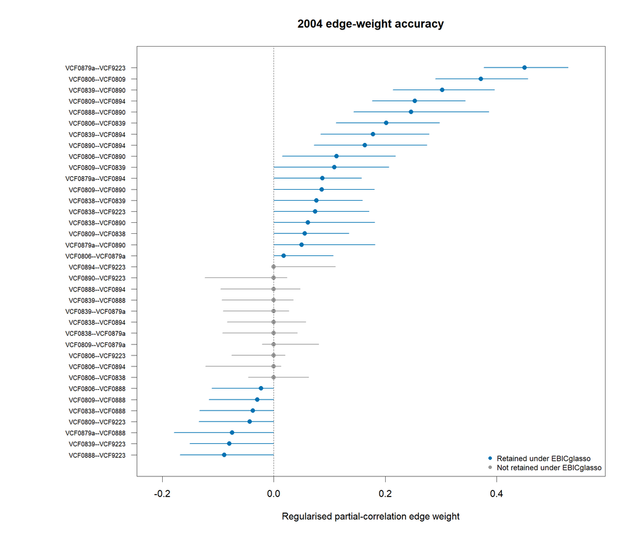

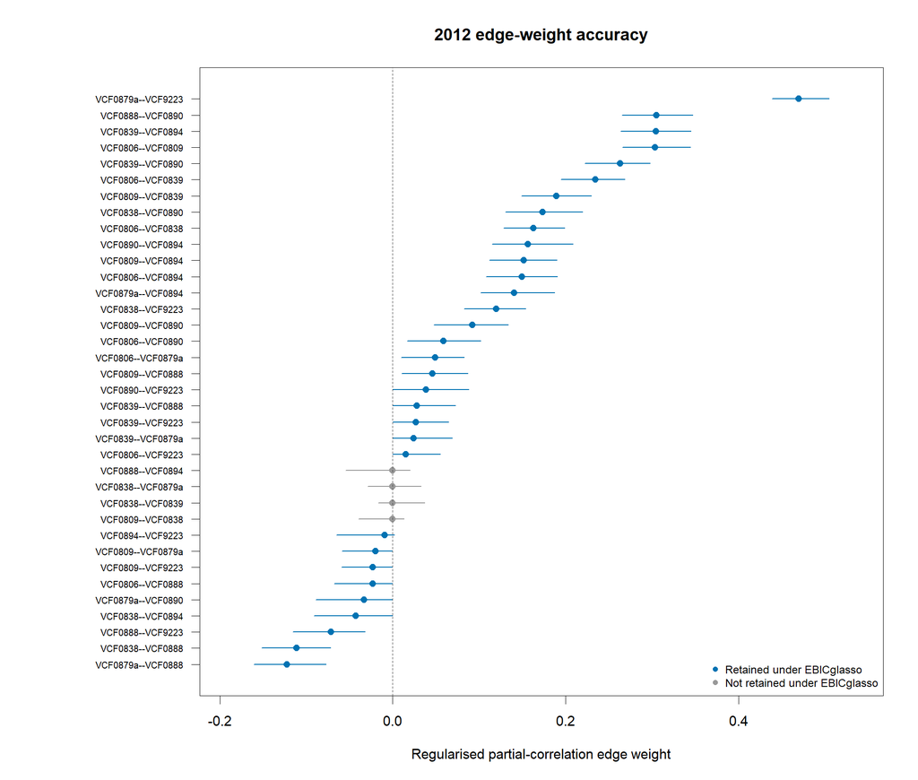

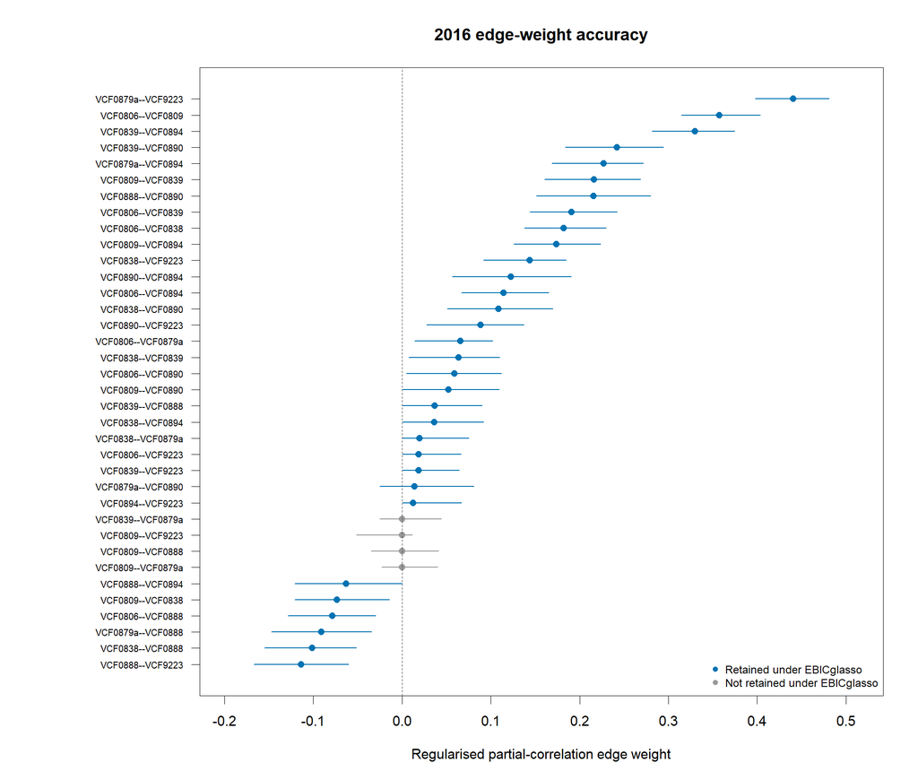